# Veena Chebrolu_Week 8_Final Exam

Veena Chebrolu

2024-07-10

```r
library(survival)
data(pbc)
?pbc
```

[output not shown]

```r
summary(pbc)
```

```
##        id             time          status            trt
##  Min.   :  1.0   Min.   :  41   Min.   :0.0000   Min.   :1.000
##  1st Qu.:105.2   1st Qu.:1093   1st Qu.:0.0000   1st Qu.:1.000
##  Median :209.5   Median :1730   Median :0.0000   Median :1.000
##  Mean   :209.5   Mean   :1918   Mean   :0.8301   Mean   :1.494
##  3rd Qu.:313.8   3rd Qu.:2614   3rd Qu.:2.0000   3rd Qu.:2.000
##  Max.   :418.0   Max.   :4795   Max.   :2.0000   Max.   :2.000
##                                                  NA's   :106
##       age        sex        ascites            hepato          spiders
##  Min.   :26.28   m: 44   Min.   :0.00000   Min.   :0.0000   Min.   :0.0000
##  1st Qu.:42.83   f:374   1st Qu.:0.00000   1st Qu.:0.0000   1st Qu.:0.0000
##  Median :51.00           Median :0.00000   Median :1.0000   Median :0.0000
##  Mean   :50.74           Mean   :0.07692   Mean   :0.5128   Mean   :0.2885
##  3rd Qu.:58.24           3rd Qu.:0.00000   3rd Qu.:1.0000   3rd Qu.:1.0000
##  Max.   :78.44           Max.   :1.00000   Max.   :1.0000   Max.   :1.0000
##                          NA's   :106       NA's   :106      NA's   :106
##      edema             bili             chol           albumin
##  Min.   :0.0000   Min.   : 0.300   Min.   : 120.0   Min.   :1.960
##  1st Qu.:0.0000   1st Qu.: 0.800   1st Qu.: 249.5   1st Qu.:3.243
##  Median :0.0000   Median : 1.400   Median : 309.5   Median :3.530
##  Mean   :0.1005   Mean   : 3.221   Mean   : 369.5   Mean   :3.497
##  3rd Qu.:0.0000   3rd Qu.: 3.400   3rd Qu.: 400.0   3rd Qu.:3.770
##  Max.   :1.0000   Max.   :28.000   Max.   :1775.0   Max.   :4.640
##                                    NA's   :134
##      copper          alk.phos            ast              trig
##  Min.   :  4.00   Min.   :  289.0   Min.   : 26.35   Min.   : 33.00
##  1st Qu.: 41.25   1st Qu.:  871.5   1st Qu.: 80.60   1st Qu.: 84.25
##  Median : 73.00   Median : 1259.0   Median :114.70   Median :108.00
##  Mean   : 97.65   Mean   : 1982.7   Mean   :122.56   Mean   :124.70
##  3rd Qu.:123.00   3rd Qu.: 1980.0   3rd Qu.:151.90   3rd Qu.:151.00
##  Max.   :588.00   Max.   :13862.4   Max.   :457.25   Max.   :598.00
##  NA's   :108      NA's   :106       NA's   :106      NA's   :136
##     platelet        protime          stage
##  Min.   : 62.0   Min.   : 9.00   Min.   :1.000
##  1st Qu.:188.5   1st Qu.:10.00   1st Qu.:2.000
##  Median :251.0   Median :10.60   Median :3.000
##  Mean   :257.0   Mean   :10.73   Mean   :3.024
##  3rd Qu.:318.0   3rd Qu.:11.10   3rd Qu.:4.000
##  Max.   :721.0   Max.   :18.00   Max.   :4.000
##  NA's   :11      NA's   :2       NA's   :6
```

# Q1: Use the code below for converting a couple of variables into factors, from their original type. What is the purpose behind these conversions? Base you answer in the contextual information related to the dataset. This information can be pulled up by using the help function on pbc.

```r
my.pbc <- na.omit(pbc[, -1])

#status as factor
my.pbc$status <- as.factor(my.pbc$status)

#ascites as factor
my.pbc$ascites <- as.factor(my.pbc$ascites)

#hepato as factor
my.pbc$hepato <- as.factor(my.pbc$hepato)

#stage as ordinal/rank
my.pbc$stage <- as.factor(my.pbc$stage)

summary(my.pbc)
```

```
##       time      status       trt             age        sex     ascites hepato
##  Min.   :  41   0:147   Min.   :1.000   Min.   :26.28   m: 34   0:257   0:134
##  1st Qu.:1186   1: 18   1st Qu.:1.000   1st Qu.:41.51   f:242   1: 19   1:142
##  Median :1788   2:111   Median :2.000   Median :49.71
##  Mean   :1979           Mean   :1.507   Mean   :49.80
##  3rd Qu.:2690           3rd Qu.:2.000   3rd Qu.:56.58
##  Max.   :4556           Max.   :2.000   Max.   :78.44
##     spiders           edema             bili             chol
##  Min.   :0.0000   Min.   :0.0000   Min.   : 0.300   Min.   : 120.0
##  1st Qu.:0.0000   1st Qu.:0.0000   1st Qu.: 0.800   1st Qu.: 249.5
##  Median :0.0000   Median :0.0000   Median : 1.400   Median : 310.0
##  Mean   :0.2899   Mean   :0.1069   Mean   : 3.334   Mean   : 371.3
##  3rd Qu.:1.0000   3rd Qu.:0.0000   3rd Qu.: 3.525   3rd Qu.: 401.0
##  Max.   :1.0000   Max.   :1.0000   Max.   :28.000   Max.   :1775.0
##     albumin          copper          alk.phos            ast
##  Min.   :1.960   Min.   :  4.00   Min.   :  289.0   Min.   : 28.38
##  1st Qu.:3.310   1st Qu.: 42.75   1st Qu.:  922.5   1st Qu.: 82.46
##  Median :3.545   Median : 74.00   Median : 1277.5   Median :116.62
##  Mean   :3.517   Mean   :100.77   Mean   : 1996.6   Mean   :124.12
##  3rd Qu.:3.772   3rd Qu.:129.25   3rd Qu.: 2068.2   3rd Qu.:153.45
##  Max.   :4.400   Max.   :588.00   Max.   :13862.4   Max.   :457.25
##       trig          platelet        protime      stage
##  Min.   : 33.0   Min.   : 62.0   Min.   : 9.00   1: 12
##  1st Qu.: 85.0   1st Qu.:200.0   1st Qu.:10.00   2: 59
##  Median :108.0   Median :257.0   Median :10.60   3:111
##  Mean   :125.0   Mean   :261.8   Mean   :10.74   4: 94
##  3rd Qu.:151.2   3rd Qu.:318.2   3rd Qu.:11.20
##  Max.   :598.0   Max.   :563.0   Max.   :17.10
```

# Interpretation:

[output not shown]

# Q2: a: Execute the code below associated with excluding trt, time, and status from the dataframe to produce a reduced version of the dataset represented by the data frame object labeled my.pbc.

## ignoring trt, time, and status, creating a reduced dataset

```r
# Creating a reduced dataset by excluding the first three columns
my.reduced.pbc <- my.pbc[, -c(1:3)]

# Displaying the first few rows of the reduced dataset to verify
head(my.reduced.pbc)
```

```
##        age sex ascites hepato spiders edema bili chol albumin copper alk.phos
## 1 58.76523   f       1      1       1   1.0 14.5  261    2.60    156   1718.0
## 2 56.44627   f       0      1       1   0.0  1.1  302    4.14     54   7394.8
## 3 70.07255   m       0      0       0   0.5  1.4  176    3.48    210    516.0
## 4 54.74059   f       0      1       1   0.5  1.8  244    2.54     64   6121.8
## 5 38.10541   f       0      1       1   0.0  3.4  279    3.53    143    671.0
## 7 55.53457   f       0      1       0   0.0  1.0  322    4.09     52    824.0
##      ast trig platelet protime stage
## 1 137.95  172      190    12.2     4
## 2 113.52   88      221    10.6     3
## 3  96.10   55      151    12.0     4
## 4  60.63   92      183    10.3     4
## 5 113.15   72      136    10.9     3
## 7  60.45  213      204     9.7     3
```

# Interpretation:

[output not shown]

# Q2 b: What would be a suitable model to predict presence of hepatomegaly or enlarged liver using age, sex, albumin, alk.phos , ast, and biliin using the reduced version of the dataset (represented by the dataframe object with the label my.reduced.pbc)? Explain the rationale behind the specific modeling approach you have choose, based on the measurement type of the outcome variable.

[output not shown]

# Q2 c: Explain the purpose behind excluding the variables trt, time, and status variables as predictors: what is gained by excluding these variables as predictors? What would be a consequence if these three variables were retained and used as predictors?

[output not shown]

# Q3: Based on your answer for Q2 b, using my.reduced.pbc dataframe , build a model to predict hepato using age, sex, albumin, alk.phos , ast, and biliin

```r
model_hepato <- glm(hepato ~ age + sex + albumin + alk.phos + ast + bili, data = my.reduced.pbc, family = "binomial")

summary(model_hepato)
```

```
##
## Call:
## glm(formula = hepato ~ age + sex + albumin + alk.phos + ast +
##     bili, family = "binomial", data = my.reduced.pbc)
##
## Coefficients:
##               Estimate Std. Error z value Pr(>|z|)
## (Intercept)  3.895e+00  1.846e+00   2.109  0.03491 *
## age          1.463e-04  1.331e-02   0.011  0.99123
## sexf        -4.393e-01  4.052e-01  -1.084  0.27835
## albumin     -1.127e+00  3.788e-01  -2.975  0.00293 **
## alk.phos     8.450e-05  6.426e-05   1.315  0.18851
## ast         -8.970e-04  2.672e-03  -0.336  0.73709
## bili         1.600e-01  5.138e-02   3.115  0.00184 **
## ---
## Signif. codes:  0 '***' 0.001 '**' 0.01 '*' 0.05 '.' 0.1 ' ' 1
##
## (Dispersion parameter for binomial family taken to be 1)
##
##     Null deviance: 382.39  on 275  degrees of freedom
## Residual deviance: 340.36  on 269  degrees of freedom
## AIC: 354.36
##
## Number of Fisher Scoring iterations: 5
```

# Interpretation:

[output not shown]

# Q3a: Significant Predictors

# Interpretation:

```
         After fitting the logistic regression model, one can investigate significant predictors based on the p values related to the respective coefficients. Usually, indicators with significance coefficients are less than a specified significance level.
```

# Q3b: Interpreting the Odds Ratio

```r
# Extract coefficients and confidence intervals
coef <- summary(model_hepato)$coefficients

# Odds ratio for bili
exp(coef['bili', 'Estimate'])
```

```
## [1] 1.173551
```

# Interpretation:

[output not shown]

# Q4: For the model constructed in Q3, perform the needed key diagnostics and interpret the results of the model based on what you find here.

```r
library(dplyr)
```

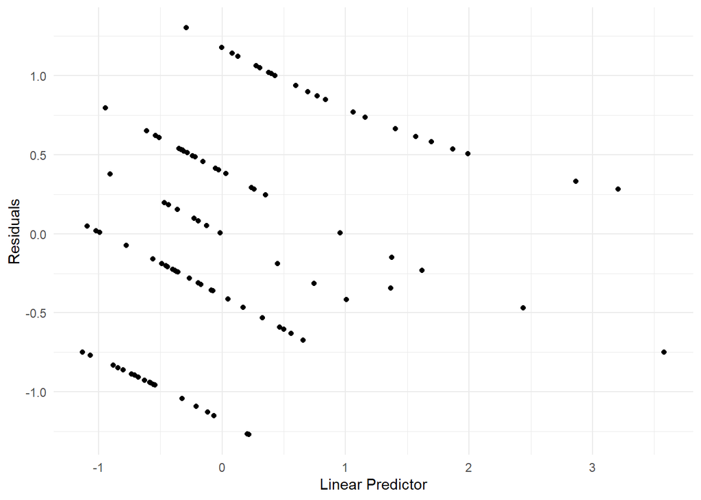

```r
library(ggplot2)
library(faraway)
# Assuming `model_hepato` and `my.reduced.pbc` are already defined

# Calculate residuals and linear predictors
my.reduced.pbc <- my.reduced.pbc %>%
  mutate(residuals = residuals(model_hepato),
         linpred = predict(model_hepato))

# Group by quantiles of the linear predictor
gdf <- my.reduced.pbc %>%
  group_by(linpred_quantile = cut(linpred, breaks = unique(quantile(linpred, (1:100)/101)))) %>%
  summarise(residuals = mean(residuals), linpred = mean(linpred))

# Plot the residuals vs linear predictor
ggplot(gdf, aes(x = linpred, y = residuals)) +
  geom_point() +
  labs(x = "Linear Predictor", y = "Residuals") +
  theme_minimal()
```

# Interpretation:

[output not shown]

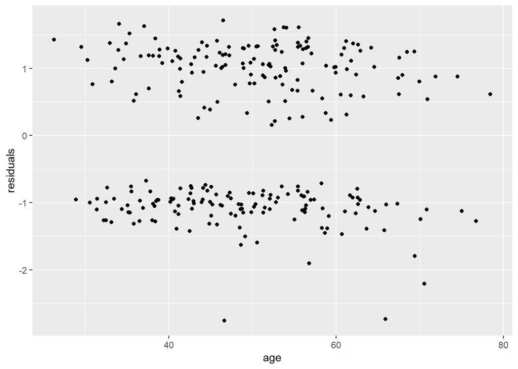

```r
# Age
group_by(my.reduced.pbc, age) %>%
  summarise(residuals = mean(residuals)) %>%
  ggplot(aes(x = age, y = residuals)) + geom_point()
```

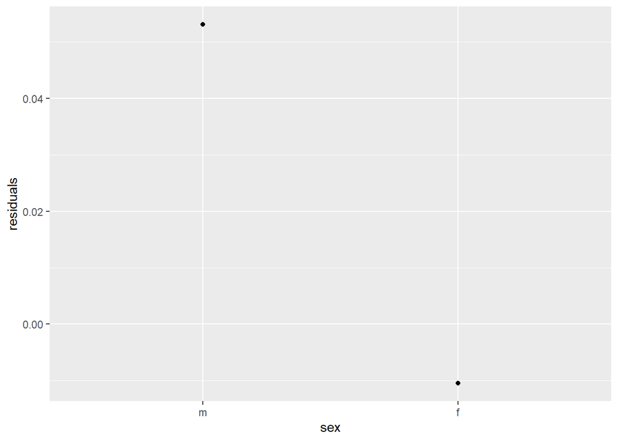

```r
# Sex
group_by(my.reduced.pbc, sex) %>%
  summarise(residuals = mean(residuals)) %>%
  ggplot(aes(x = sex, y = residuals)) + geom_point()
```

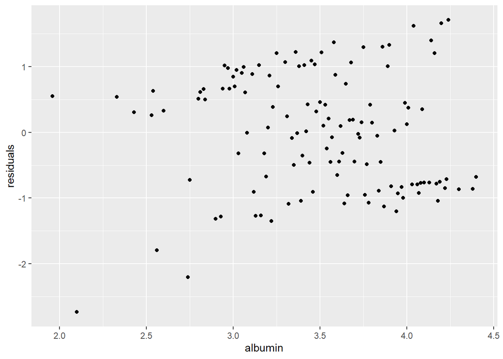

```r
# Albumin
group_by(my.reduced.pbc, albumin) %>%
  summarise(residuals = mean(residuals)) %>%
  ggplot(aes(x = albumin, y = residuals)) + geom_point()
```

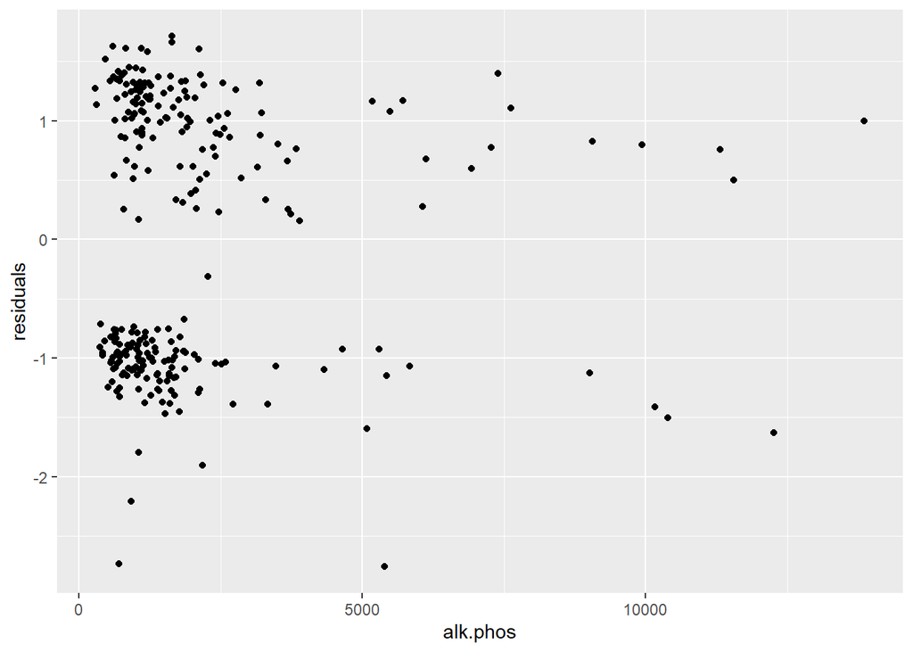

```r
# Alk.phos
group_by(my.reduced.pbc, alk.phos) %>%
  summarise(residuals = mean(residuals)) %>%
  ggplot(aes(x = alk.phos, y = residuals)) + geom_point()
```

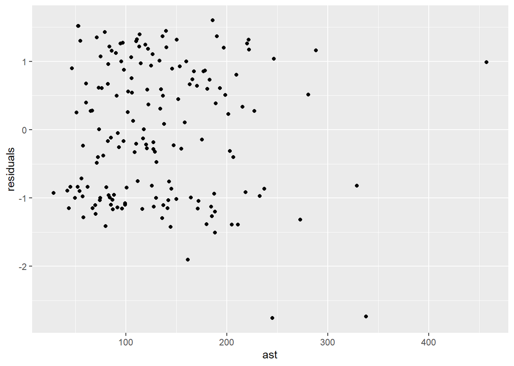

```r
# Ast
group_by(my.reduced.pbc, ast) %>%
  summarise(residuals = mean(residuals)) %>%
  ggplot(aes(x = ast, y = residuals)) + geom_point()
```

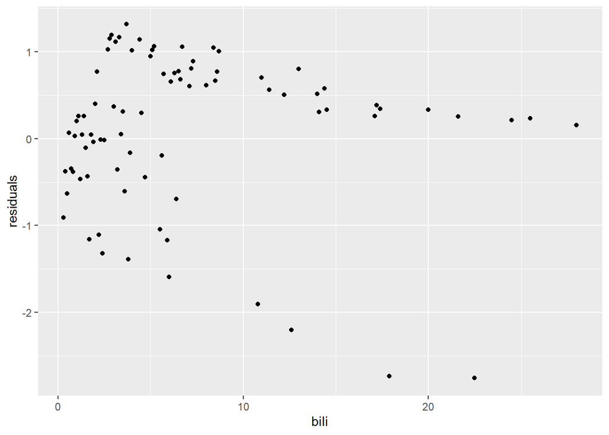

```r
# Bili
group_by(my.reduced.pbc, bili) %>%
  summarise(residuals = mean(residuals)) %>%
  ggplot(aes(x = bili, y = residuals)) + geom_point()
```

# Interpretation:

[output not shown]

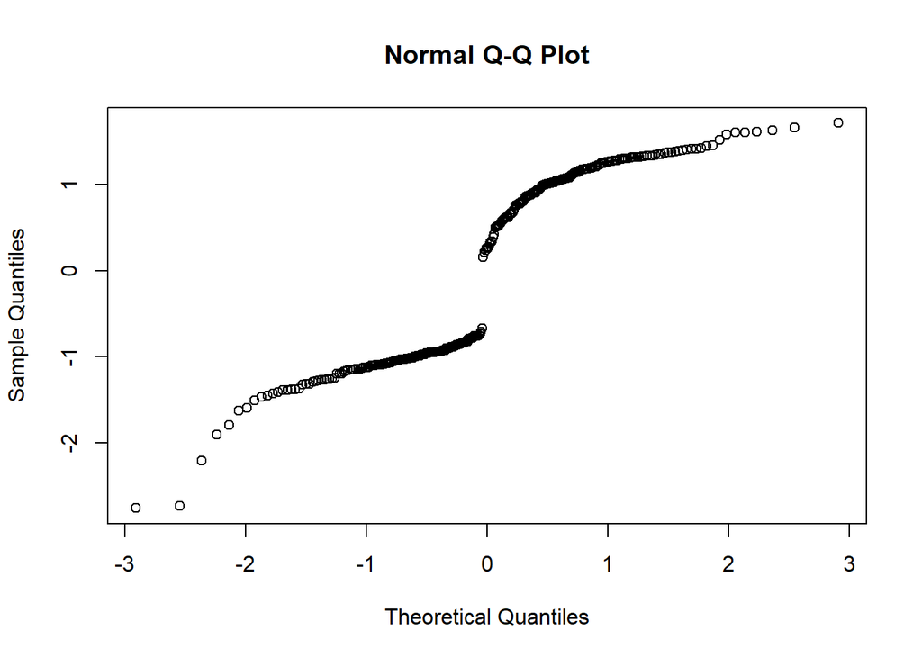

```r
qqnorm(residuals(model_hepato))
```

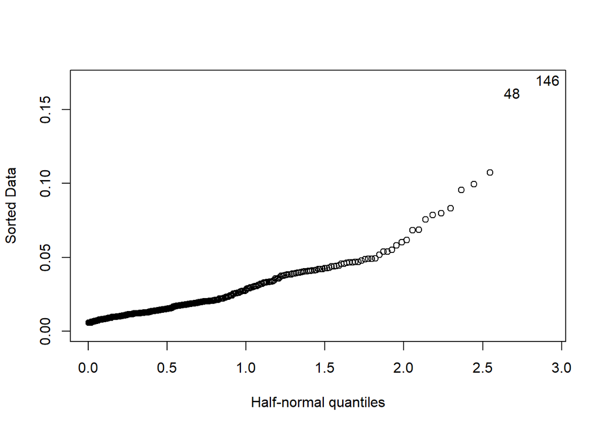

```r
halfnorm(hatvalues(model_hepato))
```

# Interpretation:

Normal Q-Q Plot:

```
The normal Q-Q plot aims at comparing the distribution of the given sample data with the normal distribution. The points are far from the straight line, particularly at the extreme ends of the graph, which demonstrate that the distribution of data is not normal. The deviations indicate the existence of outliers in the data or cannot be ruled out because the distribution is heavy-tailed.
```

Half-Normal Plot:

```
The half-normal plot evaluates the sorted observed data against half-normal theory quantiles. It mainly runs along the straight line but departs from the straight line at a higher value, and the reason for this is that the data contains more outliers than a normal distribution. It has been possible to mark out two points, namely 48 and 146, that point at certain observations that are way off from what can be expected in the normal distribution and could very well be outliers.
```

# Q5: Next, use the code below and go back to using my.pbc. Add a new variable to represent two states of status: the original status values of 0 and 1 are mapped to a 0 and the original value of 2 onto a 1. In the R code, this new variable is labeled newstatus. What purpose would be served by combining the original 0 (censored) and 1 (transplant) into a single category, and the original 2 (dead) into another single category? (Hint: consider what you would need for status, if your goal is to model survival/non-survival). What is lost when combining the original 0 and 1 categories into a single new category? How will this affect the interpretation of the results?

## Next, using my.pbc, create a new “event” variable to represent 0 and 1 as alive, and 2 as dead

## so 0 -> 0, 1 -> 0, 2 -> 1

```r
# Create the new variable newstatus
my.pbc$newstatus <- as.numeric(ifelse(my.pbc$status == 2, 1, 0))

# Remove the original status variable from the dataset
my.pbc <- my.pbc[, -2]

# Check the summary of the updated dataset
summary(my.pbc)
```

```
##       time           trt             age        sex     ascites hepato
##  Min.   :  41   Min.   :1.000   Min.   :26.28   m: 34   0:257   0:134
##  1st Qu.:1186   1st Qu.:1.000   1st Qu.:41.51   f:242   1: 19   1:142
##  Median :1788   Median :2.000   Median :49.71
##  Mean   :1979   Mean   :1.507   Mean   :49.80
##  3rd Qu.:2690   3rd Qu.:2.000   3rd Qu.:56.58
##  Max.   :4556   Max.   :2.000   Max.   :78.44
##     spiders           edema             bili             chol
##  Min.   :0.0000   Min.   :0.0000   Min.   : 0.300   Min.   : 120.0
##  1st Qu.:0.0000   1st Qu.:0.0000   1st Qu.: 0.800   1st Qu.: 249.5
##  Median :0.0000   Median :0.0000   Median : 1.400   Median : 310.0
##  Mean   :0.2899   Mean   :0.1069   Mean   : 3.334   Mean   : 371.3
##  3rd Qu.:1.0000   3rd Qu.:0.0000   3rd Qu.: 3.525   3rd Qu.: 401.0
##  Max.   :1.0000   Max.   :1.0000   Max.   :28.000   Max.   :1775.0
##     albumin          copper          alk.phos            ast
##  Min.   :1.960   Min.   :  4.00   Min.   :  289.0   Min.   : 28.38
##  1st Qu.:3.310   1st Qu.: 42.75   1st Qu.:  922.5   1st Qu.: 82.46
##  Median :3.545   Median : 74.00   Median : 1277.5   Median :116.62
##  Mean   :3.517   Mean   :100.77   Mean   : 1996.6   Mean   :124.12
##  3rd Qu.:3.772   3rd Qu.:129.25   3rd Qu.: 2068.2   3rd Qu.:153.45
##  Max.   :4.400   Max.   :588.00   Max.   :13862.4   Max.   :457.25
##       trig          platelet        protime      stage     newstatus
##  Min.   : 33.0   Min.   : 62.0   Min.   : 9.00   1: 12   Min.   :0.0000
##  1st Qu.: 85.0   1st Qu.:200.0   1st Qu.:10.00   2: 59   1st Qu.:0.0000
##  Median :108.0   Median :257.0   Median :10.60   3:111   Median :0.0000
##  Mean   :125.0   Mean   :261.8   Mean   :10.74   4: 94   Mean   :0.4022
##  3rd Qu.:151.2   3rd Qu.:318.2   3rd Qu.:11.20           3rd Qu.:1.0000
##  Max.   :598.0   Max.   :563.0   Max.   :17.10           Max.   :1.0000
```

# Interpretation:

[output not shown]

# Q6: Fit a CoxPH model to predict the hazard function of newstatus using age+sex+albumin+alk.phos+ast+bili . Identify significant predictors?

```r
# Load necessary library
library(survival)

# Assuming my.pbc is already loaded in your environment and newstatus has been created

# Fit the Cox proportional hazards model
coxPH_model <- coxph(Surv(time, newstatus) ~ age + sex + albumin + alk.phos + ast + bili, data = my.pbc)

# Display the summary of the model to identify significant predictors
summary(coxPH_model)
```

```
## Call:
## coxph(formula = Surv(time, newstatus) ~ age + sex + albumin +
##     alk.phos + ast + bili, data = my.pbc)
##
##   n= 276, number of events= 111
##
##                coef  exp(coef)   se(coef)      z Pr(>|z|)
## age       3.817e-02  1.039e+00  1.054e-02  3.621 0.000293 ***
## sexf     -5.080e-01  6.017e-01  2.662e-01 -1.909 0.056322 .
## albumin  -1.324e+00  2.661e-01  2.530e-01 -5.233 1.67e-07 ***
## alk.phos  1.926e-05  1.000e+00  3.657e-05  0.527 0.598424
## ast       2.937e-03  1.003e+00  1.605e-03  1.830 0.067309 .
## bili      1.238e-01  1.132e+00  1.598e-02  7.748 9.32e-15 ***
## ---
## Signif. codes:  0 '***' 0.001 '**' 0.01 '*' 0.05 '.' 0.1 ' ' 1
##
##          exp(coef) exp(-coef) lower .95 upper .95
## age         1.0389     0.9625    1.0177    1.0606
## sexf        0.6017     1.6619    0.3571    1.0138
## albumin     0.2661     3.7579    0.1621    0.4369
## alk.phos    1.0000     1.0000    0.9999    1.0001
## ast         1.0029     0.9971    0.9998    1.0061
## bili        1.1318     0.8835    1.0969    1.1679
##
## Concordance= 0.813  (se = 0.022 )
## Likelihood ratio test= 127.9  on 6 df,   p=<2e-16
## Wald test            = 146.5  on 6 df,   p=<2e-16
## Score (logrank) test = 208.5  on 6 df,   p=<2e-16
```

# Interpretation:

[output not shown]

# Q7: Identify the key assumption(s) associated with the CoxPH modeling approach, and explain whether it/they are satisfied, using appropriate evidence.

```r
# Load necessary library
library(survival)

# Fit the Cox proportional hazards model
coxPH_model <- coxph(Surv(time, newstatus) ~ age + sex + albumin + alk.phos + ast + bili, data = my.pbc)

# Test the proportional hazards assumption
ph_test <- cox.zph(coxPH_model)

# Display the results of the test
print(ph_test)
```

```
##            chisq df     p
## age       1.1820  1 0.277
## sex       0.0364  1 0.849
## albumin   0.7477  1 0.387
## alk.phos  0.9330  1 0.334
## ast       0.5804  1 0.446
## bili      8.2985  1 0.004
## GLOBAL   10.8236  6 0.094
```

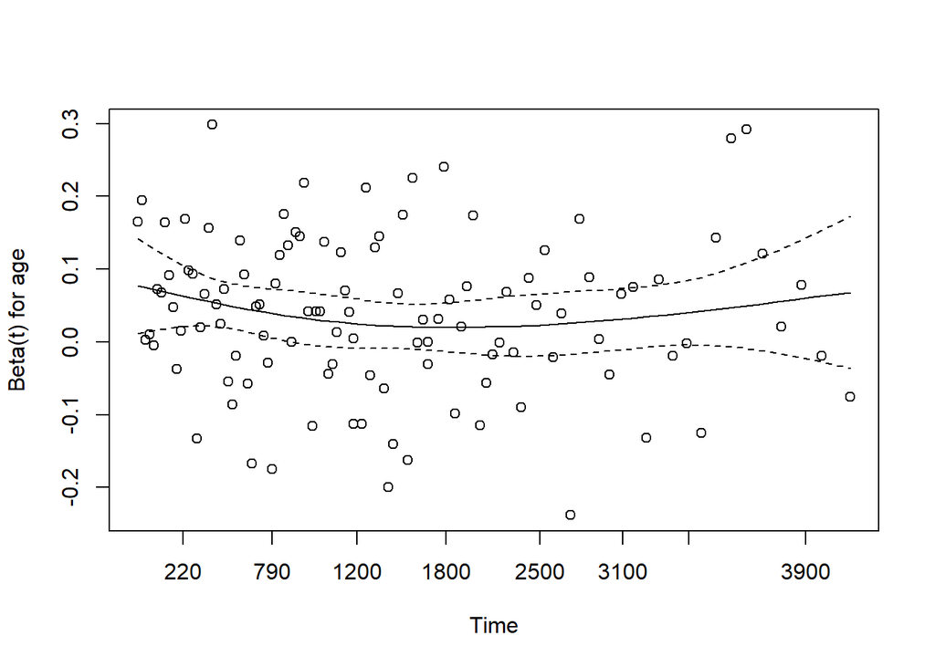

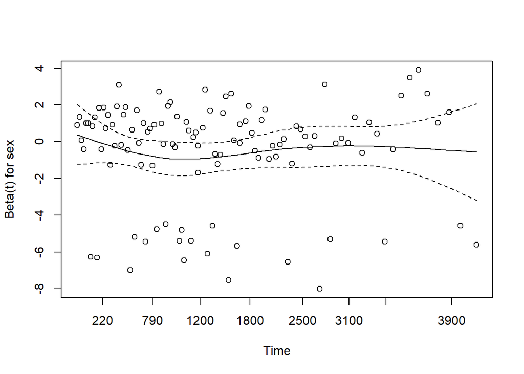

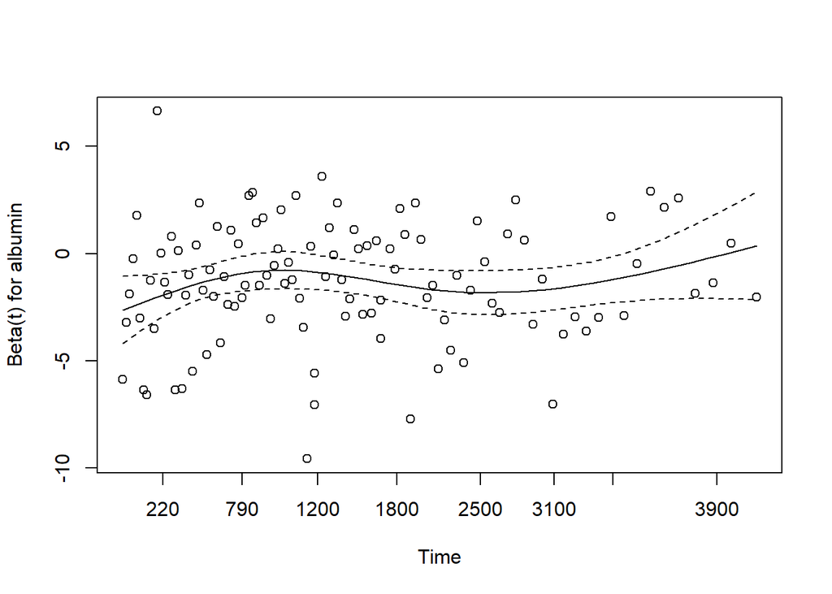

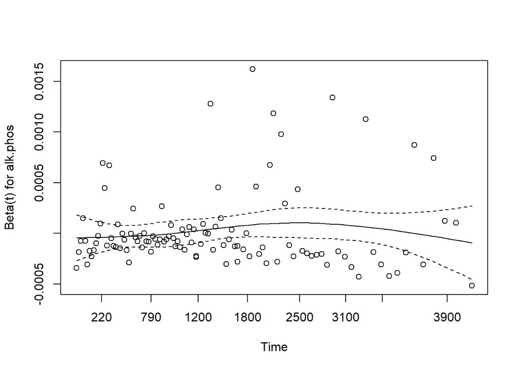

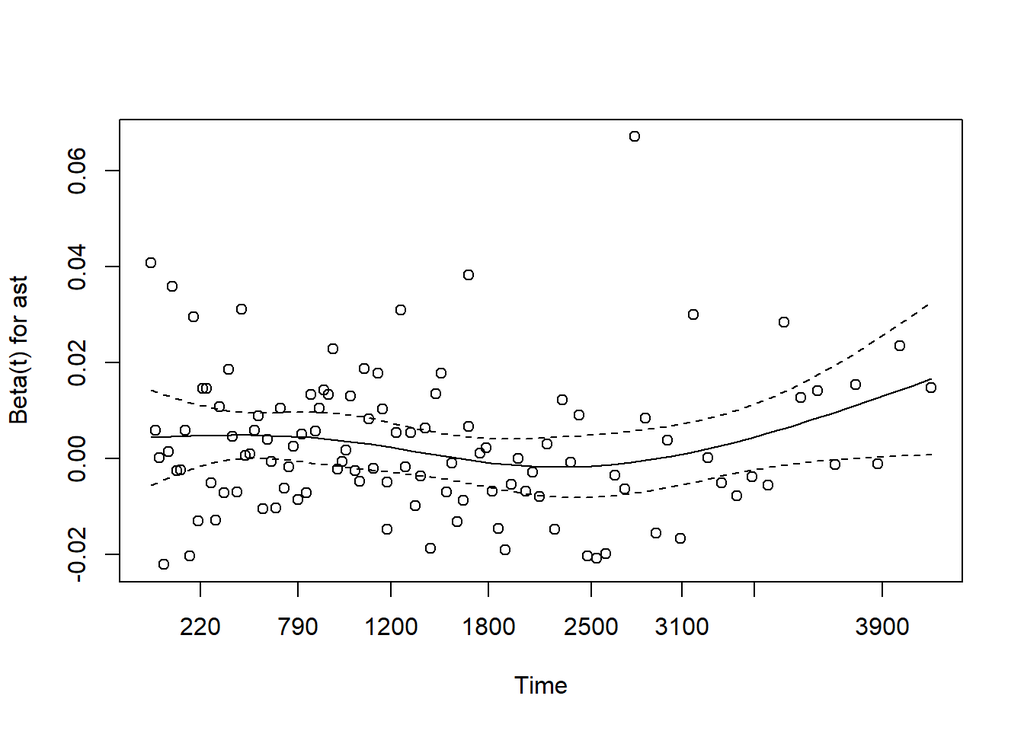

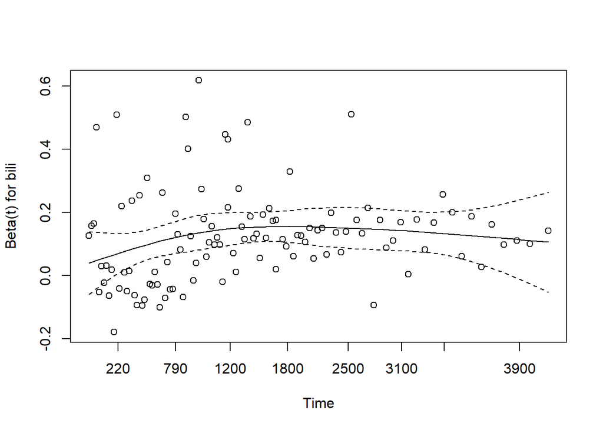

```r
# Plot Schoenfeld residuals to visually inspect proportionality
plot(ph_test)
```

# Interpretation:

[output not shown]

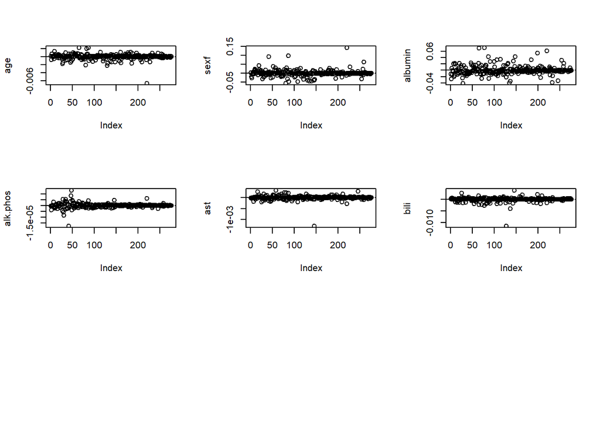

```r
# Calculate DFBETA values
dfbeta <- residuals(coxPH_model, type = "dfbeta")

# Plot DFBETA values
par(mfrow = c(3, 3))
for (j in 1:6) {
  plot(dfbeta[, j], ylab = names(coef(coxPH_model))[j])
  abline(h = 0, lty = 2)
}
```

# Interpretation:

[output not shown]

# Q8: Which aspects of the course material did you find most challenging, and why?

[output not shown]

# Q9: Looking forward, what areas within inferential modeling or data science do you wish to explore further? Please specify any techniques, theories, or applications you are interested in and explain how deepening your knowledge in these areas could benefit your future studies or career goals.

[output not shown]